# Statistics in Python: Pearson Correlation Coefficient

⇦ Back

The **Pearson Correlation Coefficient**, *r*, can be calculated from data where the dependent and independent variables are both *continuous*, where a confounding factor exists (ie the independent variable is *not truly independent*) and where the *parametric* assumptions are met.

[interactive chart not shown]

**Python Packages:**

The code on this page uses the `pandas`, `matplotlib`, `scipy`, and `numpy` packages. These can be installed from the terminal with:

```bash
$ python3.11 -m pip install pandas
$ python3.11 -m pip install matplotlib
$ python3.11 -m pip install scipy
$ python3.11 -m pip install numpy
```

where `python3.11` corresponds to the version of Python you have installed and are using.

# 1 Example Data

Let’s use the following example data set from Giavarina’s paper.[^1] Imagine that a set of objects were each measured twice - once using ‘Method A’ and once using ‘Method B’ - giving the two lists of measurements shown below:

```python
import pandas as pd

dct = {
    'Method A': [
        1.0, 5.0, 10.0, 20.0, 50.0, 40.0, 50.0, 60.0, 70.0, 80.0, 90.0, 100.0,
        150.0, 200.0, 250.0, 300.0, 350.0, 400.0, 450.0, 500.0, 550.0, 600.0,
        650.0, 700.0, 750.0, 800.0, 850.0, 900.0, 950.0, 1000.0
    ],
    'Method B': [
        8.0, 16.0, 30.0, 24.0, 39.0, 54.0, 40.0, 68.0, 72.0, 62.0, 122.0, 80.0,
        181.0, 259.0, 275.0, 380.0, 320.0, 434.0, 479.0, 587.0, 626.0, 648.0,
        738.0, 766.0, 793.0, 851.0, 871.0, 957.0, 1001.0, 960.0
    ]
}
df = pd.DataFrame(dct)
```

These can be visualised on a scatter plot:

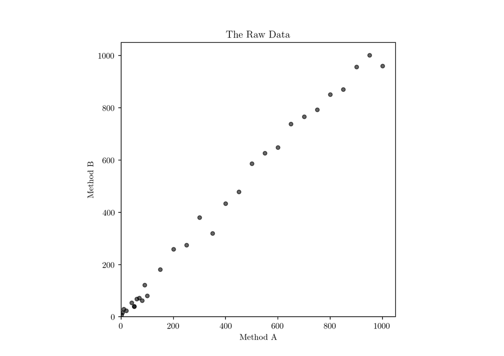

```python
import matplotlib.pyplot as plt

# Formatting options for plots
A = 5  # Want figures to be A5
plt.rc('figure', figsize=[46.82 * .5**(.5 * A), 33.11 * .5**(.5 * A)])
plt.rc('text', usetex=True)  # Use LaTeX
plt.rc('font', family='serif')  # Use a serif font
plt.rc('text.latex', preamble=r'\usepackage{textgreek}')  # Load Greek letters

# Create plot
ax = plt.axes()
ax.scatter(df['Method A'], df['Method B'], c='k', s=20, alpha=0.6, marker='o')
# Labels
ax.set_title('The Raw Data')
ax.set_xlabel('Method A')
ax.set_ylabel('Method B')
# Get axis limits
left, right = ax.get_xlim()
# Set axis limits
ax.set_xlim(0, right)
ax.set_ylim(0, right)
# Set aspect ratio
ax.set_aspect('equal')
# Show plot
plt.show()
```

These points seem to roughly show a straight-line relationship, but let’s be a bit more precise and start to quantify *exactly* how much they correlate…

# 2 Pearson Correlation Coefficient, *r*

As described on its [Wikipedia page](https://en.wikipedia.org/wiki/Pearson_correlation_coefficient), the Pearson *r* statistic measures linear correlation between two variables. It assumes that a set of data points can be approximated by a straight line and returns a value that describes how strong the linear correlation is:

- +1 is total positive linear correlation (the data points all lie on a straight line with a positive gradient)
- 0 is no linear correlation (the data points are randomly scattered all over the plot area)
- −1 is total negative linear correlation (the data points all lie on a straight line with a negative gradient)

For more precise interpretations of the absolute value of *r* the follow can be used as a guideline[^2]:

- 0 to 0.19: very weak correlation
- 0.2 to 0.39: weak correlation
- 0.4 to 0.59: moderate correlation
- 0.6 to 0.79: strong correlation
- 0.8 to 1: very strong correlation

…and here’s how to calculate it:

```python
import scipy.stats as st
import numpy as np

# Pearson correlation coefficient, r
x = df['Method A']
y = df['Method B']
r, p = st.pearsonr(x, y)

# Transform r into a z-score via Fisher transformation
r_z = np.arctanh(r)  # These two ways are equivalent
r_z = 0.5 * np.log((1 + r) / (1 - r))  # These two ways are equivalent
# Sample size
n = len(df)
# Standard error
se = 1 / np.sqrt(n - 3)
# Significance level, α
alpha = 0.05  # 95% confidence level
# Number of tails
tails = 2
# Quantile (the cumulative probability)
q = 1 - (alpha / tails)
# Critical z-score, calculated using the percent-point function (aka the
# quantile function) of the normal distribution
z_crit = st.norm.ppf(q)
# Confidence interval in z-space
low_z, high_z = r_z - z_crit * se, r_z + z_crit * se
# Transform back into r-space
low, high = np.tanh((low_z, high_z))

print(f'r = {r:5.3f}, 95% CI: [{low:5.3f}, {high:5.3f}]; p = {p:.2e}')
```

```
## r = 0.996, 95% CI: [0.991, 0.998]; p = 1.26e-30
```

This *r*-value is close to 1, which confirms that the points nearly follow a straight line. Let’s visualise this by using the *r* statistic to generate a line of best fit:

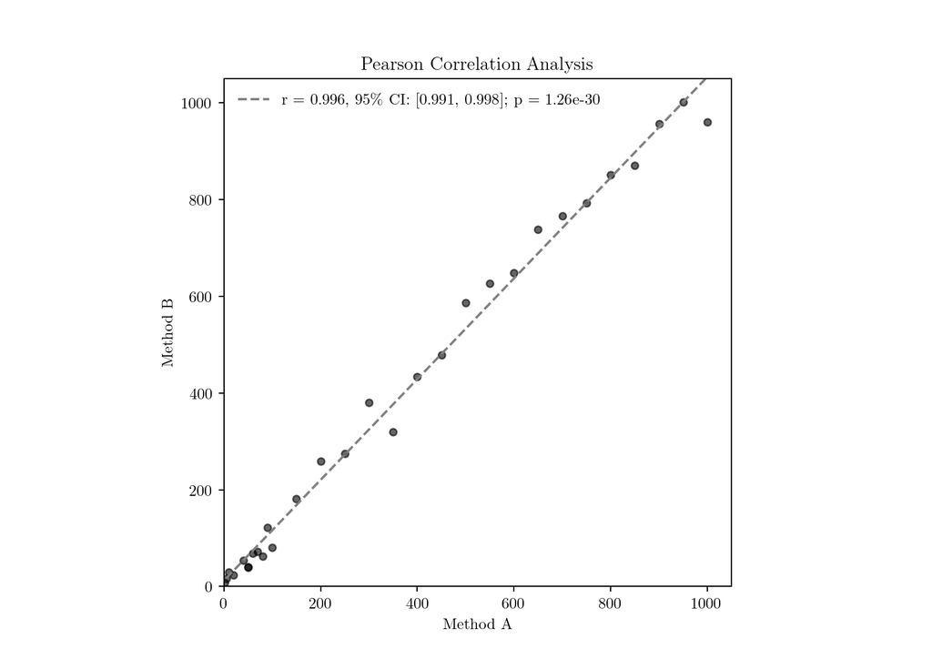

```python
# Pearson correlation coefficient, r
r, p = st.pearsonr(x, y)
# Gradient of line of best fit
m = r * np.std(y) / np.std(x)
# Y-intercept of line of best-fit
c = np.mean(y) - m * np.mean(x)

# Create plot
ax = plt.axes()
ax.scatter(df['Method A'], df['Method B'], c='k', s=20, alpha=0.6, marker='o')
# Get axis limits
left, right = ax.get_xlim()
# Set axis limits
ax.set_xlim(0, right)
ax.set_ylim(0, right)
# Line of best fit
x = np.array([left, right])
y = m * x + c
label = rf'r = {r:5.3f}, 95\% CI: [{low:5.3f}, {high:5.3f}]; p = {p:.2e}'
ax.plot(x, y, c='grey', ls='--', label=label)
# Labels
ax.set_title('Pearson Correlation Analysis')
ax.set_xlabel('Method A')
ax.set_ylabel('Method B')
# Set aspect ratio
ax.set_aspect('equal')
# Legend
ax.legend(frameon=False)
# Show plot
plt.show()
```

# 3 As a Custom Function

It’s often more useful to be able to do this calculation in a function so that it can be easily called as many times as you need it:

```python
def pearson_correlation_coefficient(x, y):
    """Calculate Pearson's r with confidence interval and significance."""
    r, p = st.pearsonr(x, y)
    # Transform r into a z-score via Fisher transformation
    r_z = np.arctanh(r)
    # Sample size
    n = len(df)
    # Standard error
    se = 1 / np.sqrt(n - 3)
    # Significance level, α
    alpha = 0.05  # 95% confidence level
    # Number of tails
    tails = 2
    # Quantile (the cumulative probability)
    q = 1 - (alpha / tails)
    # Critical z-score, calculated using the percent-point function (aka the
    # quantile function) of the normal distribution
    z_crit = st.norm.ppf(q)
    # Confidence interval in z-space
    low_z, high_z = r_z - z_crit * se, r_z + z_crit * se
    # Transform back into r-space
    low, high = np.tanh((low_z, high_z))

    return r, low, high, p


x = df['Method A']
y = df['Method B']
r, ci_lower, ci_upper, p = pearson_correlation_coefficient(x, y)

print(f'r = {r:5.3f}, 95% CI: [{ci_lower:5.3f}, {ci_upper:5.3f}]; p = {p:.2e}')
```

```
## r = 0.996, 95% CI: [0.991, 0.998]; p = 1.26e-30
```

⇦ Back

[^1]: Giavarina, D. “Understanding Bland Altman analysis”. Biochemia Medica 2015; 25(2):141-151. DOI: 10.11613/BM.2015.015. PMID: 26110027. Available [here](https://www.ncbi.nlm.nih.gov/pmc/articles/PMC4470095/pdf/bm-25-141.pdf). Jump to reference:
[^2]: Swinscow, TDV. Study design and choosing a statistical test. In: Campbell, MJ, editors. Statistics at Square One. BMJ Publishing Group; 1997. Available [here](https://www.bmj.com/about-bmj/resources-readers/publications/statistics-square-one/13-study-design-and-choosing-statisti). Jump to reference: